# Risk Factor Analysis

## Outcome Variable

**Outcome Variable:** y_rate_haz

## Predictor Variables

**Intervention Variable:** parity

**Adjustment Set:**

unadjusted

## Stratifying Variables

The analysis was stratified on these variable(s):

- diffcat
- studyid
- country

## Data Summary

| diffcat | studyid | country | parity | n_cell | n |
| --- | --- | --- | --- | --- | --- |
| 12-24 months | ki1000110-WASH-Bangladesh | BANGLADESH | 1 | 13 | 38 |
| 12-24 months | ki1000110-WASH-Bangladesh | BANGLADESH | 2 | 18 | 38 |
| 12-24 months | ki1000110-WASH-Bangladesh | BANGLADESH | 3+ | 7 | 38 |
| 0-3 months | ki1017093b-PROVIDE | BANGLADESH | 1 | 240 | 634 |
| 0-3 months | ki1017093b-PROVIDE | BANGLADESH | 2 | 225 | 634 |
| 0-3 months | ki1017093b-PROVIDE | BANGLADESH | 3+ | 169 | 634 |
| 3-6 months | ki1017093b-PROVIDE | BANGLADESH | 1 | 206 | 574 |
| 3-6 months | ki1017093b-PROVIDE | BANGLADESH | 2 | 211 | 574 |
| 3-6 months | ki1017093b-PROVIDE | BANGLADESH | 3+ | 157 | 574 |
| 6-12 months | ki1017093b-PROVIDE | BANGLADESH | 1 | 197 | 545 |
| 6-12 months | ki1017093b-PROVIDE | BANGLADESH | 2 | 201 | 545 |
| 6-12 months | ki1017093b-PROVIDE | BANGLADESH | 3+ | 147 | 545 |
| 12-24 months | ki1017093b-PROVIDE | BANGLADESH | 1 | 168 | 458 |
| 12-24 months | ki1017093b-PROVIDE | BANGLADESH | 2 | 174 | 458 |
| 12-24 months | ki1017093b-PROVIDE | BANGLADESH | 3+ | 116 | 458 |
| 0-3 months | kiGH5241-JiVitA-3 | BANGLADESH | 1 | 6375 | 20028 |
| 0-3 months | kiGH5241-JiVitA-3 | BANGLADESH | 2 | 6945 | 20028 |
| 0-3 months | kiGH5241-JiVitA-3 | BANGLADESH | 3+ | 6708 | 20028 |
| 3-6 months | kiGH5241-JiVitA-3 | BANGLADESH | 1 | 4401 | 12573 |
| 3-6 months | kiGH5241-JiVitA-3 | BANGLADESH | 2 | 4359 | 12573 |
| 3-6 months | kiGH5241-JiVitA-3 | BANGLADESH | 3+ | 3813 | 12573 |
| 6-12 months | kiGH5241-JiVitA-3 | BANGLADESH | 1 | 3364 | 9832 |
| 6-12 months | kiGH5241-JiVitA-3 | BANGLADESH | 2 | 3495 | 9832 |
| 6-12 months | kiGH5241-JiVitA-3 | BANGLADESH | 3+ | 2973 | 9832 |
| 12-24 months | kiGH5241-JiVitA-3 | BANGLADESH | 1 | 1531 | 4648 |
| 12-24 months | kiGH5241-JiVitA-3 | BANGLADESH | 2 | 1653 | 4648 |
| 12-24 months | kiGH5241-JiVitA-3 | BANGLADESH | 3+ | 1464 | 4648 |
| 12-24 months | ki1112895-Burkina Faso Zn | BURKINA FASO | 1 | 2 | 12 |
| 12-24 months | ki1112895-Burkina Faso Zn | BURKINA FASO | 2 | 2 | 12 |
| 12-24 months | ki1112895-Burkina Faso Zn | BURKINA FASO | 3+ | 8 | 12 |

[output cut: 101 more lines]

The following strata were considered:

- diffcat: 0-3 months, studyid: ki1000304b-SAS-CompFeed, country: INDIA
- diffcat: 0-3 months, studyid: ki1017093b-PROVIDE, country: BANGLADESH
- diffcat: 0-3 months, studyid: ki1033518-iLiNS-DYAD-G, country: GHANA
- diffcat: 0-3 months, studyid: ki1101329-Keneba, country: GAMBIA
- diffcat: 0-3 months, studyid: ki1126311-ZVITAMBO, country: ZIMBABWE
- diffcat: 0-3 months, studyid: ki1135781-COHORTS, country: GUATEMALA
- diffcat: 0-3 months, studyid: ki1135781-COHORTS, country: INDIA
- diffcat: 0-3 months, studyid: kiGH5241-JiVitA-3, country: BANGLADESH
- diffcat: 12-24 months, studyid: ki1000110-WASH-Bangladesh, country: BANGLADESH
- diffcat: 12-24 months, studyid: ki1017093b-PROVIDE, country: BANGLADESH
- diffcat: 12-24 months, studyid: ki1066203-TanzaniaChild2, country: TANZANIA, UNITED REPUBLIC OF
- diffcat: 12-24 months, studyid: ki1101329-Keneba, country: GAMBIA
- diffcat: 12-24 months, studyid: ki1112895-Burkina Faso Zn, country: BURKINA FASO
- diffcat: 12-24 months, studyid: ki1113344-GMS-Nepal, country: NEPAL
- diffcat: 12-24 months, studyid: ki1126311-ZVITAMBO, country: ZIMBABWE
- diffcat: 12-24 months, studyid: ki1135781-COHORTS, country: GUATEMALA
- diffcat: 12-24 months, studyid: ki1135781-COHORTS, country: INDIA
- diffcat: 12-24 months, studyid: ki1135781-COHORTS, country: PHILIPPINES
- diffcat: 12-24 months, studyid: ki1148112-iLiNS-DYAD-M, country: MALAWI
- diffcat: 12-24 months, studyid: kiGH5241-JiVitA-3, country: BANGLADESH
- diffcat: 3-6 months, studyid: ki1000304b-SAS-CompFeed, country: INDIA
- diffcat: 3-6 months, studyid: ki1017093b-PROVIDE, country: BANGLADESH
- diffcat: 3-6 months, studyid: ki1033518-iLiNS-DYAD-G, country: GHANA
- diffcat: 3-6 months, studyid: ki1066203-TanzaniaChild2, country: TANZANIA, UNITED REPUBLIC OF
- diffcat: 3-6 months, studyid: ki1101329-Keneba, country: GAMBIA
- diffcat: 3-6 months, studyid: ki1113344-GMS-Nepal, country: NEPAL
- diffcat: 3-6 months, studyid: ki1126311-ZVITAMBO, country: ZIMBABWE
- diffcat: 3-6 months, studyid: ki1135781-COHORTS, country: GUATEMALA
- diffcat: 3-6 months, studyid: ki1135781-COHORTS, country: INDIA
- diffcat: 3-6 months, studyid: ki1148112-iLiNS-DYAD-M, country: MALAWI
- diffcat: 3-6 months, studyid: kiGH5241-JiVitA-3, country: BANGLADESH
- diffcat: 6-12 months, studyid: ki1000304b-SAS-CompFeed, country: INDIA
- diffcat: 6-12 months, studyid: ki1000304b-SAS-FoodSuppl, country: INDIA
- diffcat: 6-12 months, studyid: ki1017093b-PROVIDE, country: BANGLADESH
- diffcat: 6-12 months, studyid: ki1033518-iLiNS-DYAD-G, country: GHANA
- diffcat: 6-12 months, studyid: ki1066203-TanzaniaChild2, country: TANZANIA, UNITED REPUBLIC OF
- diffcat: 6-12 months, studyid: ki1101329-Keneba, country: GAMBIA
- diffcat: 6-12 months, studyid: ki1113344-GMS-Nepal, country: NEPAL
- diffcat: 6-12 months, studyid: ki1126311-ZVITAMBO, country: ZIMBABWE
- diffcat: 6-12 months, studyid: ki1135781-COHORTS, country: GUATEMALA
- diffcat: 6-12 months, studyid: ki1135781-COHORTS, country: INDIA
- diffcat: 6-12 months, studyid: ki1135781-COHORTS, country: PHILIPPINES
- diffcat: 6-12 months, studyid: ki1148112-iLiNS-DYAD-M, country: MALAWI
- diffcat: 6-12 months, studyid: kiGH5241-JiVitA-3, country: BANGLADESH

### Dropped Strata

Some strata were dropped due to rare outcomes:

- diffcat: 12-24 months, studyid: ki1112895-Burkina Faso Zn, country: BURKINA FASO
- diffcat: 3-6 months, studyid: ki1148112-iLiNS-DYAD-M, country: MALAWI
- diffcat: 12-24 months, studyid: ki1066203-TanzaniaChild2, country: TANZANIA, UNITED REPUBLIC OF

## Methods Detail

We’re interested in the causal parameters $E[Y_a]$ for all values of $a \in \mathcal{A}$. These parameters represent the mean outcome if, possibly contrary to fact, we intervened to set all units to have $A=a$. Under the randomization and positivity assumptions, these are identified by the statistical parameters $\psi_a=E_W[E_{Y|A,W}(Y|A=a,W)]$. In addition, we’re interested in the mean of $Y$, $E[Y]$ under no intervention (the observed mean). We will estimate these parameters by using SuperLearner to fit the relevant likelihood factors – $E_{Y|A,W}(Y|A=a,W)$ and $p(A=a|W)$, and then updating our likelihood fit using a joint TMLE.

For unadjusted analyses ($W=\{\}$), initial likelihoods were estimated using Lrnr_glm to estimate the simple $E(Y|A)$ and Lrnr_mean to estimate $p(A)$. For adjusted analyses, a small library containing Lrnr_glmnet, Lrnr_xgboost, and Lrnr_mean was used.

Having estimated these parameters, we will then use the delta method to estimate relative risks and attributable risks relative to a prespecified baseline level of $A$.

# Results Detail

## Results Plots

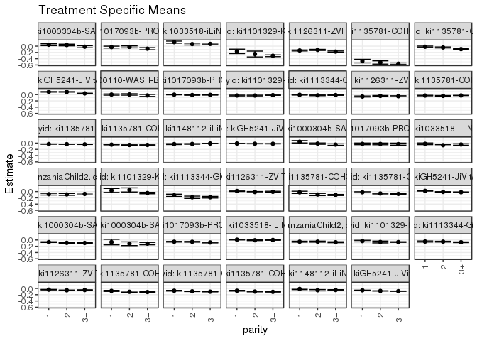

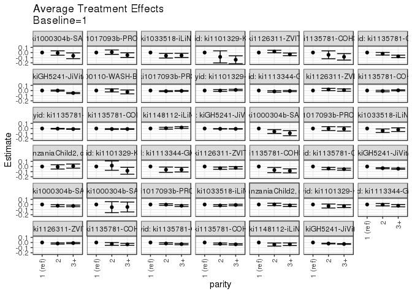

## Results Table

### Parameter: TSM

| diffcat | studyid | country | intervention_level | baseline_level | estimate | ci_lower | ci_upper |
| --- | --- | --- | --- | --- | --- | --- | --- |
| 0-3 months | ki1000304b-SAS-CompFeed | INDIA | 1 | NA | 0.0457264 | 0.0162017 | 0.0752511 |
| 0-3 months | ki1000304b-SAS-CompFeed | INDIA | 2 | NA | 0.0362877 | 0.0096830 | 0.0628924 |
| 0-3 months | ki1000304b-SAS-CompFeed | INDIA | 3+ | NA | -0.0174816 | -0.0505822 | 0.0156190 |
| 0-3 months | ki1017093b-PROVIDE | BANGLADESH | 1 | NA | -0.0303678 | -0.0602506 | -0.0004850 |
| 0-3 months | ki1017093b-PROVIDE | BANGLADESH | 2 | NA | -0.0229772 | -0.0535483 | 0.0075938 |
| 0-3 months | ki1017093b-PROVIDE | BANGLADESH | 3+ | NA | -0.0812729 | -0.1148770 | -0.0476688 |
| 0-3 months | ki1033518-iLiNS-DYAD-G | GHANA | 1 | NA | 0.1279744 | 0.0948841 | 0.1610646 |
| 0-3 months | ki1033518-iLiNS-DYAD-G | GHANA | 2 | NA | 0.0657321 | 0.0358698 | 0.0955944 |
| 0-3 months | ki1033518-iLiNS-DYAD-G | GHANA | 3+ | NA | 0.0713983 | 0.0476910 | 0.0951057 |
| 0-3 months | ki1101329-Keneba | GAMBIA | 1 | NA | -0.1663073 | -0.2374224 | -0.0951922 |
| 0-3 months | ki1101329-Keneba | GAMBIA | 2 | NA | -0.2507579 | -0.3434489 | -0.1580670 |
| 0-3 months | ki1101329-Keneba | GAMBIA | 3+ | NA | -0.3068050 | -0.3350095 | -0.2786005 |
| 0-3 months | ki1126311-ZVITAMBO | ZIMBABWE | 1 | NA | -0.1380525 | -0.1548653 | -0.1212396 |
| 0-3 months | ki1126311-ZVITAMBO | ZIMBABWE | 2 | NA | -0.1192061 | -0.1374016 | -0.1010106 |
| 0-3 months | ki1126311-ZVITAMBO | ZIMBABWE | 3+ | NA | -0.1733052 | -0.1925415 | -0.1540688 |
| 0-3 months | ki1135781-COHORTS | GUATEMALA | 1 | NA | -0.4760672 | -0.5329807 | -0.4191537 |
| 0-3 months | ki1135781-COHORTS | GUATEMALA | 2 | NA | -0.5206196 | -0.5720523 | -0.4691869 |
| 0-3 months | ki1135781-COHORTS | GUATEMALA | 3+ | NA | -0.5598980 | -0.5864487 | -0.5333472 |
| 0-3 months | ki1135781-COHORTS | INDIA | 1 | NA | -0.0189129 | -0.0388819 | 0.0010562 |
| 0-3 months | ki1135781-COHORTS | INDIA | 2 | NA | -0.0421539 | -0.0585457 | -0.0257620 |
| 0-3 months | ki1135781-COHORTS | INDIA | 3+ | NA | -0.0941666 | -0.1063970 | -0.0819362 |
| 0-3 months | kiGH5241-JiVitA-3 | BANGLADESH | 1 | NA | 0.0872287 | 0.0792520 | 0.0952054 |
| 0-3 months | kiGH5241-JiVitA-3 | BANGLADESH | 2 | NA | 0.0863147 | 0.0789673 | 0.0936621 |
| 0-3 months | kiGH5241-JiVitA-3 | BANGLADESH | 3+ | NA | 0.0383710 | 0.0308606 | 0.0458815 |
| 3-6 months | ki1000304b-SAS-CompFeed | INDIA | 1 | NA | 0.0426044 | 0.0051106 | 0.0800982 |
| 3-6 months | ki1000304b-SAS-CompFeed | INDIA | 2 | NA | -0.0164802 | -0.0374816 | 0.0045212 |
| 3-6 months | ki1000304b-SAS-CompFeed | INDIA | 3+ | NA | -0.0481116 | -0.0736767 | -0.0225465 |
| 3-6 months | ki1017093b-PROVIDE | BANGLADESH | 1 | NA | -0.0242729 | -0.0508171 | 0.0022713 |
| 3-6 months | ki1017093b-PROVIDE | BANGLADESH | 2 | NA | -0.0259679 | -0.0534464 | 0.0015106 |
| 3-6 months | ki1017093b-PROVIDE | BANGLADESH | 3+ | NA | -0.0328530 | -0.0651061 | -0.0006000 |

[output cut: 93 more lines]

### Parameter: E(Y)

| diffcat | studyid | country | intervention_level | baseline_level | estimate | ci_lower | ci_upper |
| --- | --- | --- | --- | --- | --- | --- | --- |
| 0-3 months | ki1000304b-SAS-CompFeed | INDIA | NA | NA | 0.0123467 | -0.0036133 | 0.0283068 |
| 0-3 months | ki1017093b-PROVIDE | BANGLADESH | NA | NA | -0.0413143 | -0.0594662 | -0.0231624 |
| 0-3 months | ki1033518-iLiNS-DYAD-G | GHANA | NA | NA | 0.0871908 | 0.0704561 | 0.1039256 |
| 0-3 months | ki1101329-Keneba | GAMBIA | NA | NA | -0.2853220 | -0.3108085 | -0.2598355 |
| 0-3 months | ki1126311-ZVITAMBO | ZIMBABWE | NA | NA | -0.1428480 | -0.1532568 | -0.1324391 |
| 0-3 months | ki1135781-COHORTS | GUATEMALA | NA | NA | -0.5431999 | -0.5652020 | -0.5211979 |
| 0-3 months | ki1135781-COHORTS | INDIA | NA | NA | -0.0684794 | -0.0774008 | -0.0595580 |
| 0-3 months | kiGH5241-JiVitA-3 | BANGLADESH | NA | NA | 0.0705478 | 0.0655933 | 0.0755023 |
| 3-6 months | ki1000304b-SAS-CompFeed | INDIA | NA | NA | -0.0166348 | -0.0360336 | 0.0027639 |
| 3-6 months | ki1017093b-PROVIDE | BANGLADESH | NA | NA | -0.0272428 | -0.0436954 | -0.0107902 |
| 3-6 months | ki1033518-iLiNS-DYAD-G | GHANA | NA | NA | -0.0443716 | -0.0584690 | -0.0302741 |
| 3-6 months | ki1066203-TanzaniaChild2 | TANZANIA, UNITED REPUBLIC OF | NA | NA | -0.0840487 | -0.1007413 | -0.0673560 |
| 3-6 months | ki1101329-Keneba | GAMBIA | NA | NA | -0.0278645 | -0.0482582 | -0.0074707 |
| 3-6 months | ki1113344-GMS-Nepal | NEPAL | NA | NA | -0.1659967 | -0.1845182 | -0.1474752 |
| 3-6 months | ki1126311-ZVITAMBO | ZIMBABWE | NA | NA | -0.0009676 | -0.0102953 | 0.0083602 |
| 3-6 months | ki1135781-COHORTS | GUATEMALA | NA | NA | -0.0963382 | -0.1109683 | -0.0817082 |
| 3-6 months | ki1135781-COHORTS | INDIA | NA | NA | -0.0633737 | -0.0703095 | -0.0564379 |
| 3-6 months | kiGH5241-JiVitA-3 | BANGLADESH | NA | NA | -0.0034446 | -0.0083108 | 0.0014217 |
| 6-12 months | ki1000304b-SAS-CompFeed | INDIA | NA | NA | -0.0862318 | -0.0909003 | -0.0815633 |
| 6-12 months | ki1000304b-SAS-FoodSuppl | INDIA | NA | NA | -0.1077712 | -0.1389671 | -0.0765754 |
| 6-12 months | ki1017093b-PROVIDE | BANGLADESH | NA | NA | -0.0626151 | -0.0695574 | -0.0556729 |
| 6-12 months | ki1033518-iLiNS-DYAD-G | GHANA | NA | NA | 0.0011158 | -0.0049386 | 0.0071703 |
| 6-12 months | ki1066203-TanzaniaChild2 | TANZANIA, UNITED REPUBLIC OF | NA | NA | -0.0595335 | -0.0687862 | -0.0502807 |
| 6-12 months | ki1101329-Keneba | GAMBIA | NA | NA | -0.0627772 | -0.0712590 | -0.0542954 |
| 6-12 months | ki1113344-GMS-Nepal | NEPAL | NA | NA | -0.0614960 | -0.0697225 | -0.0532696 |
| 6-12 months | ki1126311-ZVITAMBO | ZIMBABWE | NA | NA | -0.0492642 | -0.0539207 | -0.0446077 |
| 6-12 months | ki1135781-COHORTS | GUATEMALA | NA | NA | -0.1091173 | -0.1161782 | -0.1020564 |
| 6-12 months | ki1135781-COHORTS | INDIA | NA | NA | -0.0957304 | -0.1001246 | -0.0913361 |
| 6-12 months | ki1135781-COHORTS | PHILIPPINES | NA | NA | -0.0999391 | -0.1050516 | -0.0948266 |
| 6-12 months | ki1148112-iLiNS-DYAD-M | MALAWI | NA | NA | -0.0453210 | -0.0549106 | -0.0357313 |
| 6-12 months | kiGH5241-JiVitA-3 | BANGLADESH | NA | NA | -0.0748465 | -0.0776904 | -0.0720026 |
| 12-24 months | ki1000110-WASH-Bangladesh | BANGLADESH | NA | NA | -0.0026893 | -0.0170438 | 0.0116652 |
| 12-24 months | ki1017093b-PROVIDE | BANGLADESH | NA | NA | -0.0081718 | -0.0120131 | -0.0043304 |
| 12-24 months | ki1101329-Keneba | GAMBIA | NA | NA | -0.0201573 | -0.0242768 | -0.0160377 |
| 12-24 months | ki1113344-GMS-Nepal | NEPAL | NA | NA | -0.0155649 | -0.0206065 | -0.0105234 |
| 12-24 months | ki1126311-ZVITAMBO | ZIMBABWE | NA | NA | -0.0517435 | -0.0609232 | -0.0425638 |
| 12-24 months | ki1135781-COHORTS | GUATEMALA | NA | NA | -0.0295389 | -0.0332082 | -0.0258696 |
| 12-24 months | ki1135781-COHORTS | INDIA | NA | NA | -0.0374666 | -0.0395050 | -0.0354283 |
| 12-24 months | ki1135781-COHORTS | PHILIPPINES | NA | NA | -0.0576520 | -0.0601763 | -0.0551277 |
| 12-24 months | ki1148112-iLiNS-DYAD-M | MALAWI | NA | NA | -0.0199208 | -0.0250725 | -0.0147691 |
| 12-24 months | kiGH5241-JiVitA-3 | BANGLADESH | NA | NA | -0.0187787 | -0.0206287 | -0.0169287 |

### Parameter: ATE

| diffcat | studyid | country | intervention_level | baseline_level | estimate | ci_lower | ci_upper |
| --- | --- | --- | --- | --- | --- | --- | --- |
| 0-3 months | ki1000304b-SAS-CompFeed | INDIA | 1 | 1 | 0.0000000 | 0.0000000 | 0.0000000 |
| 0-3 months | ki1000304b-SAS-CompFeed | INDIA | 2 | 1 | -0.0094387 | -0.0523016 | 0.0334242 |
| 0-3 months | ki1000304b-SAS-CompFeed | INDIA | 3+ | 1 | -0.0632079 | -0.1189368 | -0.0074790 |
| 0-3 months | ki1017093b-PROVIDE | BANGLADESH | 1 | 1 | 0.0000000 | 0.0000000 | 0.0000000 |
| 0-3 months | ki1017093b-PROVIDE | BANGLADESH | 2 | 1 | 0.0073905 | -0.0353596 | 0.0501406 |
| 0-3 months | ki1017093b-PROVIDE | BANGLADESH | 3+ | 1 | -0.0509051 | -0.0958742 | -0.0059360 |
| 0-3 months | ki1033518-iLiNS-DYAD-G | GHANA | 1 | 1 | 0.0000000 | 0.0000000 | 0.0000000 |
| 0-3 months | ki1033518-iLiNS-DYAD-G | GHANA | 2 | 1 | -0.0622423 | -0.1068149 | -0.0176697 |
| 0-3 months | ki1033518-iLiNS-DYAD-G | GHANA | 3+ | 1 | -0.0565761 | -0.0972824 | -0.0158698 |
| 0-3 months | ki1101329-Keneba | GAMBIA | 1 | 1 | 0.0000000 | 0.0000000 | 0.0000000 |
| 0-3 months | ki1101329-Keneba | GAMBIA | 2 | 1 | -0.0844506 | -0.2012794 | 0.0323781 |
| 0-3 months | ki1101329-Keneba | GAMBIA | 3+ | 1 | -0.1404977 | -0.2170016 | -0.0639938 |
| 0-3 months | ki1126311-ZVITAMBO | ZIMBABWE | 1 | 1 | 0.0000000 | 0.0000000 | 0.0000000 |
| 0-3 months | ki1126311-ZVITAMBO | ZIMBABWE | 2 | 1 | 0.0188464 | -0.0059276 | 0.0436203 |
| 0-3 months | ki1126311-ZVITAMBO | ZIMBABWE | 3+ | 1 | -0.0352527 | -0.0608009 | -0.0097045 |
| 0-3 months | ki1135781-COHORTS | GUATEMALA | 1 | 1 | 0.0000000 | 0.0000000 | 0.0000000 |
| 0-3 months | ki1135781-COHORTS | GUATEMALA | 2 | 1 | -0.0445524 | -0.1212627 | 0.0321579 |
| 0-3 months | ki1135781-COHORTS | GUATEMALA | 3+ | 1 | -0.0838308 | -0.1466327 | -0.0210288 |
| 0-3 months | ki1135781-COHORTS | INDIA | 1 | 1 | 0.0000000 | 0.0000000 | 0.0000000 |
| 0-3 months | ki1135781-COHORTS | INDIA | 2 | 1 | -0.0232410 | -0.0490762 | 0.0025942 |
| 0-3 months | ki1135781-COHORTS | INDIA | 3+ | 1 | -0.0752537 | -0.0986705 | -0.0518369 |
| 0-3 months | kiGH5241-JiVitA-3 | BANGLADESH | 1 | 1 | 0.0000000 | 0.0000000 | 0.0000000 |
| 0-3 months | kiGH5241-JiVitA-3 | BANGLADESH | 2 | 1 | -0.0009140 | -0.0109431 | 0.0091151 |
| 0-3 months | kiGH5241-JiVitA-3 | BANGLADESH | 3+ | 1 | -0.0488577 | -0.0593170 | -0.0383983 |
| 3-6 months | ki1000304b-SAS-CompFeed | INDIA | 1 | 1 | 0.0000000 | 0.0000000 | 0.0000000 |
| 3-6 months | ki1000304b-SAS-CompFeed | INDIA | 2 | 1 | -0.0590846 | -0.0967848 | -0.0213844 |
| 3-6 months | ki1000304b-SAS-CompFeed | INDIA | 3+ | 1 | -0.0907160 | -0.1398338 | -0.0415982 |
| 3-6 months | ki1017093b-PROVIDE | BANGLADESH | 1 | 1 | 0.0000000 | 0.0000000 | 0.0000000 |
| 3-6 months | ki1017093b-PROVIDE | BANGLADESH | 2 | 1 | -0.0016950 | -0.0399005 | 0.0365105 |
| 3-6 months | ki1017093b-PROVIDE | BANGLADESH | 3+ | 1 | -0.0085801 | -0.0503516 | 0.0331914 |

[output cut: 93 more lines]